# ECON 4/6260 - Behaviroal Economics

## Boring stuff first: Expectation for class

- We will start and finish on time
- Attendance is expected
- All due dates are final outside of excused absences
- You are checking your UToledo email
- You have read and understand the Syllabus
- For all classroom experiments, at least one person will be paid. You will understand the payment mechanism before starting an experiment.

## What will we be studying?

- Insights from Psychology
  - Especially judgment & decision-making
- Extensions of “standard” (non-behavioral) economic theory
  - Markets
  - Choice theory
  - Games
- Experimental methods
- Non-experimental methods

## Doing economic research without experiments

Research question \(\rightarrow\) I need data

- Data might not exactly answer the research question
- Often difficult to establish a causal relationship
- Often requires assumptions to be made about the data that you cannot test.

I have data \(\rightarrow\) what questions can I answer?

- Limits the questions you can answer
- Still difficult to establish a causal relationship
- Still (often) requires untestable assumptions

## Economic experiments

We will be using economic experiments to learn about concepts in Behavioral Economics.

Mostly, we will use *laboratory experiments*

- Use people who have volunteered to participate. Usually undergrads.
  - In this class: you
- Give them a task to perform, and observe their behavior.
- Pay them money based on their decisions

## Why pay money?

Mankiw’s *10 Principles of Economics*: “4. People respond to incentives”

If I pay you enough, I will have a good idea about what your incentives are.

## How this will work for ECON4/6260

- I have approval from the Department of Economics to pay you in US dollars
- If I pay you, I will need to record your name and how much I paid you
- I don’t have enough to pay everybody every time. I will randomly select (at least) one person to be paid after each experiment. You will not know who is getting paid until all decisions have been made.
- As this is an online class, I will give you several choices of how you can be paid
- This is not my money, so don’t feel badly about taking it
- Don’t rely on it for lunch, car payments, etc.

## And now for our first experiment

…

## Reasons for running an experiment

Studying theoretical predictions

- Point and comparative static predictions
- Comparing the predictions of two or more theories

Studying behavioral assumptions

- Maybe a theory performs poorly. Can we work out which assumption(s) is (are) causing this?
- E.g. Are people selfish? Do people maximize expected value? Do people ignore sunk costs?

Establishing behavioral regularities

- Does the theory make more than one prediction? (multiple equilibria)
- Explore behavior to help us make better behavioral assumptions

Further reading:

> Nikiforakis, Nikos. [“For the student: experimental economics.”](https://onlinelibrary.wiley.com/doi/full/10.1111/j.1467-8462.2010.00607.x?casa_token=K6AYdLRDvdAAAAAA%3AideO69vzWNyKiBui76sE4jOLASAPBw0JoDZ97Uxy0POWYZ_pOV-T1feeFWAOtUdY9fWIYXcFSNGe3RJ6) Australian Economic Review 43, no. 3 (2010): 337-345.

## Studying theoretical predictions - I

Suppose that you have a theory that makes a prediction \(f(x)\) for situation \(x\).

e.g.:

- When the temperature is \(x^\circ\mathrm F\), \(f(x)=10+3x\) pints of ice cream will be sold

**Point predictions**: Given situation \(x\), \(f(x)\) will happen

- When the temperature is \(90^\circ \mathrm F\), \(280 = 10 + 3\times 90\) pints of ice cream will be sold

**Comparative static predictions**: When \(x\) increases, \(f(x)\) increases (or decreases, or nothing happens to \(f(x)\))

- When temperature increases, ice cream sales increase.
- When temperature increases by \(1^\circ \mathrm F\), ice cream sales increase by 3 pints.

*When are each of these useful?*

## Studying theoretical predictions - II

**Comparing two or more theories**

I have two theories about how \(x\) affects an outcome. These theories are \(f(x)\) and \(g(x)\). I wish to understand whether one makes better predictions than another.

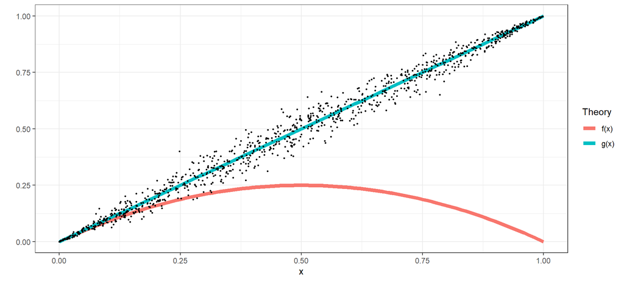

## Studying theoretical predictions - III

**Comparing two or more theories**: Sometimes both are important!

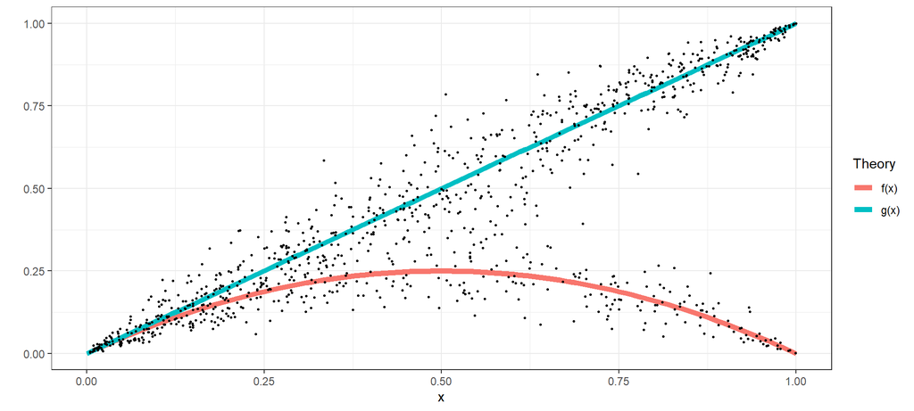

## Studying theoretical predictions - IV

**Comparing two or more theories**: Sometimes they are all useless

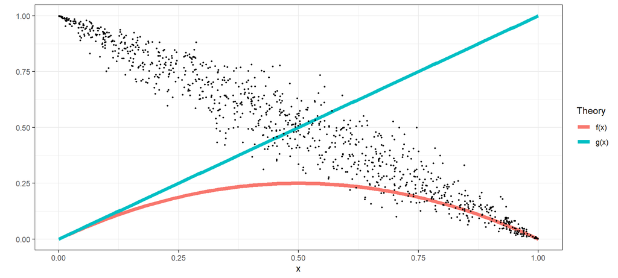

## Economic experiments and causality

Conduct a study that resembles a drug trial.

Often referred to as a “randomized controlled trial”

Drug trials:

- Randomly assign people to two groups
- One group gets the treatment (i.e. they get the drug)
- One group doesn’t get the drug (or a placebo)
- Random assignment ensures that differences between groups’ health outcomes could only be due to the drug

Economic experiments:

- Instead of health outcomes, we are interested in peoples’ decisions
- Instead of drugs, we will be treating people with *different incentives*
- Many field experiments use this format, e.g the work associated with the [2019 Nobel prize in Economics](https://www.nobelprize.org/prizes/economic-sciences/2019/press-release/)

## Complement to data from outside the lab

Example: ECON1200 model of a market.

- Buyers with values
- Sellers with costs
- If we know all of these, we can calculate the equilibrium price and quantity

Outside the lab:

- Buyers might not want to tell you their values
- Sellers will probably lie to you about costs
- We can easily observe price and quantity, but not the values and costs that got us there

Inside the lab:

- We can assign buyers and sellers values and costs
- Hence, we know what the theory predicts, and we can observe the outcomes.

## A roadmap for this course

Usually, I will introduce a topic with an experiment.

Then, you will have a homework assignment based on the data from the experiment

We will discuss this in the next class

For 6260 students, we will use our extra hour mostly as a reading group. I will assign the first few readings, but I am very open to suggestions.

## Outline of topics covered (not necessarily in order)

- Game theory
  - How do economists model interactions in small groups?
  - Key concepts: Nash Equilibrium, best response, mixed and pure strategies
  - Single-shot games, sequential games, Bayesian games
- Behavioral Game Theory
  - Incorporating insights from decision theory into game theory
  - Noisy behavior in equilibrium
  - Other departures from the *Homo Economicus* assumption
  - Non-standard preferences
- Preferences & Decisions
  - Risk
  - Probability judgment
  - Other-regarding preferences